# Practice Question 1

Author

Dr. Yu Cheng Hsu

Published

October 8, 2026

## Lab overview

You have been hired to audit data from a recent fluorescence experiment. The research team recorded the baseline fluorescence intensity of four cellular markers (**CD4**, **CD8**, **CD19**, and **CD56**) over a three-day period.

Work through each section by running the code examples and answering the questions. Answer keys and worked code are in hidden instructor blocks on the live page (and in the teacher-notes pack).

### About fluorescence experiment

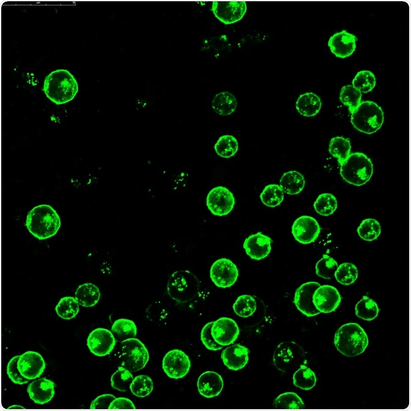

Leukemia cells labeled with fluorescent molecules

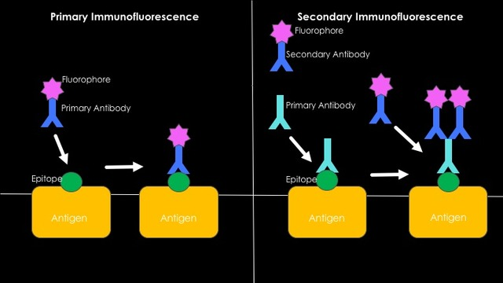

Basic mechanism of immunofluorescence

## 1. Vector arithmetic and recycling

Before opening, the below experiement results has been recorded:

- CD4: 12
- CD8: 5
- CD19: 35
- CD56: 4

### Scalar broadcasting vs. vector operations

**Questions**

1. What does R do when you multiply a vector of length 4 by a single number such as `(1 + amp_rate)` (a vector of length 1)?
2. Suppose you scramble the *names* of `fade_rates` to `c(CD56 = 0.20, CD19 = 0.15, CD8 = 0.00, CD4 = 0.05)` but leave `base_signals` in the original order. Do the usual arithmetic operators (`*`, `+`, …) match values **by name** or **by position** (1st with 1st, 2nd with 2nd)?

**Answer key**

1. **Recycling (often called broadcasting here).** R has no separate scalar type: `1 + amp_rate` is an atomic vector of length 1. R recycles that single value to length 4 so pairwise multiplication can run.
2. **By position, not by name.** Binary arithmetic ignores names. Index 1 multiplies with index 1, and so on. If `fade_rates` is reordered and `base_signals` is not, the wrong discount is applied. To align by name you would need something like `fade_rates[names(base_signals)]`.

### Indexing

Extract the `Final_Signal` column from `signal_df`. *Hint:* there are several valid approaches; try more than one.

**Questions**

1. Compare `signal_df[3, 3]` with `signal_df["CD19", "Final_Signal"]`. Which is easier for another reader to understand without looking at the data?
2. Next month a student adds a column `Sample_ID` as **column 1**, so every later column shifts one place to the right. What would `signal_df[, 3]` refer to then, compared with `signal_df[, "Final_Signal"]`? Which is less sensitive to that change?
3. Compare the printed result and `class()` of `signal_df$Final_Signal`, `signal_df["Final_Signal"]`, and `signal_df[["Final_Signal"]]`. Why does `[` **without a comma** return a one-column data frame, while `$` and `[[` extract a numeric vector?

**Answer key**

1. `signal_df["CD19", "Final_Signal"]` is clearer: it names the row and the column.
2. After inserting `Sample_ID` at the front, `signal_df[, 3]` would be the old column 2 (`Fade_Rate`). `signal_df[, "Final_Signal"]` still means final signal no matter how many columns you add, so it is the more robust choice.
3. `$` and `[[` pull out the vector stored in that column. `[` with no comma subsets the data frame as a list of columns, so `signal_df["Final_Signal"]` (and `price_df[3]` for the third column) stays a one-column `data.frame`.

### Recycling rules and warnings

**Questions**

1. Why does adding `noise_2` (length 2) to `base_signals` (length 4) run **without** a warning? What pattern of fees is applied to CD4, CD8, CD19, and CD56?
2. Why does adding `noise_3` (length 3) **warn**, and what values does R actually add to the four items?
3. Why can “even” recycling (lengths that divide evenly) be more dangerous in an audit than the warning case?

**Answer key**

1. R recycles the shorter vector until it matches the longer one. When `length(longer) %% length(shorter) == 0` (here $4 \bmod 2 = 0$), R treats the repeat as intentional and stays silent. The fees are $+1, +2, +1, +2$.
2. $4 \bmod 3 \neq 0$, so R still wraps around (the fourth item gets the first fee, $+1$) but warns: `longer object length is not a multiple of shorter object length`.
3. If someone passed `c(5, 0)`, R would add 5 to CD4 and CD9 and 0 to CD8 and CD56 with **no** warning. The code is valid, so the accounting error is easy to miss. The mismatched-length warning at least flags that something odd happened.

### Finding help with `?`

**Questions**

1. Does `round(amplified_signals)` match what you expected? *Hint:* look at values that sit exactly on `.5`, then try a few extra examples of your own.
2. Type `?round` in the console and read the **Details** section.
   - Which international standard does R follow?
   - How does that standard explain what you saw for `round(amplified_signals)`?

**Answer key**

1. Half-way cases do not always round “away from zero” or “always up”. They follow **round half to even** (the adjacent even integer).
2. IEC 60559 / IEEE 754. That is why a `.5` can round up or down depending on whether the neighbouring integer is even.

### Data types and coercion

**Questions**

**Answer key**

1. Character.
2. Character as well — one character value forces the whole vector to character — so `instrument_log[1] + instrument_log[3]` is not valid numeric addition.
3. $$\text{logical} \longrightarrow \text{integer} \longrightarrow \text{double (numeric)} \longrightarrow \text{character}$$